# **Import sound files and select signals**

*Marcelo Araya-Salas and Grace Smith Vidaurre*

2018-03-13

Here we present examples regarding how to begin the `warbleR` workflow by downloading recordings from *xeno-canto*, importing your own recordings, making spectrograms of whole recordings, selecting signals within recordings or importing selections already made in *Raven* and *Syrinx*. For more details about function arguments, input or output, read the documentation for the function in question (e.g. `?querxc`). `warbleR` is available on both [CRAN](https://cran.r-project.org/package=warbleR) and [GitHub](https://github.com/maRce10/warbleR). The GitHub repository will always contain the latest functions and updates. We also published an article on `warbleR` documenting the package workflow <sup>[1]</sup>.

Please note that most tools in `warbleR` use functions from the seewave, monitoR, tuneR and [`dtw`](https://cran.r-project.org/package=dtw) packages internally. `warbleR` has been designed to make the analyses more accessible to average R-users. However, acoustic analysis with `warbleR` would not be possible without the tools provided by these additional packages. These packages should be given credit when using `warbleR` by including the appropriate citations in publications (e.g. `citation("seewave")`).

Nearly all `warbleR` functions contain options for parallel processing, which can greatly speed up analyses. See <sup>[1]</sup> for more details about parallel processing performance. Use parallel processing with caution, particularly if you use a Windows operating system. `warbleR` dependencies for parallel processing have not yet been optimized for Windows.

This vignette can be run without an advanced understanding of R, as long as you know how to run code in your R console. However, knowing more about basic R coding would be very helpful to modify the code for your research questions.

## **Prepare for acoustic analysis**

First, we need to install and load `warbleR`. Install the package from its GitHub repository to access the latest functions presented in this vignette series. You will need an R version ≥ 2.10 and seewave package version ≥ 2.0.1. Also, users using UNIX machines (Mac OSX or Linux), will need to install `fftw3`, `pkg-config` and `libsndfile` on their machines prior to installing `warbleR`. These external packages will need to be installed through a UNIX terminal. Installing these packages lies outside the scope of this vignette, but more details can be found using Google.

```r
# install warbleR from CRAN
# install.packages("warbleR")

# install warbleR from GitHub repository, which contains the latest updates
# install.packages("devtools") # run this if devtools is not already installed
library(devtools)
install_github("maRce10/warbleR")

library(warbleR) # load warbleR into your global environment
```

Set up a working directory

```r
# Create a new directory and set your working directory
dir.create(file.path(getwd(),"warbleR_example"))
setwd(file.path(getwd(),"warbleR_example"))

# Check your location
getwd()
```

## What data do you need to use warbleR? Sound files and selections

Bioacoustics research encompasses a wide range of questions, species, geographic areas and methods, including software used for analysis. *warbleR* accounts for this diversity by offering a variety of ways to import data for analysis. Regardless of the research question(s), *warbleR* relies on the following two types of data:

1. **Sound files:** Recordings in *wav* or *mp3* format, either from your own research or open-access databases like xeno-canto
2. **Selections:** Selections are temporal coordinates (start and end points) of selected acoustic signals within recordings, often organized within a data frame called a selection table

Below we will give different examples of how to obtain recordings from the open-access database [xeno-canto](http://www.xeno-canto.org/), import recordings or selections other bioacoustics software, such as *Raven* and *Syrinx*, as well as how to make selections using *warbleR* functions.

## Obtain metadata and recordings from [xeno-canto](http://www.xeno-canto.org/)

The open-access [xeno-canto](http://www.xeno-canto.org/) database is an excellent source of sound files across a broad selection of avian species. We can query this database for a species or genus of interest. The function `querxc` has two types of output:

1. **Metadata of recordings:** geographic coordinates, recording quality, recorder, type of signal, etc.
2. **Sound files:** Sound files in *mp3* format are returned if the argument `download` is set to `TRUE` (default is `FALSE`).

We recommend downloading metadata first from *xeno-canto*, as this data can be filtered in R to more efficiently download only the recordings important for your question.

**You can query [xeno-canto](http://www.xeno-canto.org/) by genus:**

```r
# Query xeno-canto for all recordings of the hummingbird genus Phaethornis
Phae <- querxc(qword = "Phaethornis", download = FALSE)
```

```
## Obtaining recording list...806 recordings found!
```

```r
# Print column names of data frame to explore metadata
names(Phae)
```

```
##  [1] "Recording_ID"      "Genus"             "Specific_epithet"
##  [4] "Subspecies"        "English_name"      "Recordist"
##  [7] "Country"           "Locality"          "Latitude"
## [10] "Longitude"         "Vocalization_type" "Audio_file"
## [13] "License"           "Url"               "Quality"
## [16] "Time"              "Date"
```

```r
# Check out the structure of the data frame
str(Phae)
```

**Or you can query by species:**

```r
# Query xeno-canto for all recordings of the species Phaethornis longirostris
Phae.lon <- querxc(qword = "Phaethornis longirostris", download = FALSE)
str(Phae.lon)
```

```
## Obtaining recording list...76 recordings found!
```

If you’re interested in the geographic spread of the recording locations, you can use the function `xcmaps` to visualize locations. `xcmaps` will create an image file of a map per species in your current directory if `img = TRUE`. If `img = FALSE`, maps will be displayed in the graphic device.

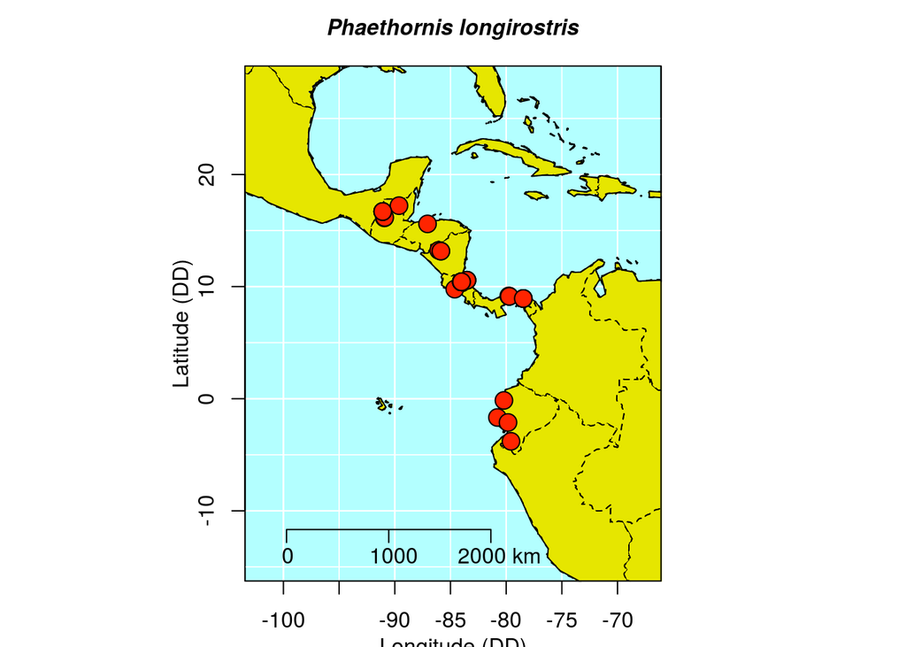

```r
# Image type default is jpeg, but tiff files have better resolution

# When the data frame contains multiple species,
# you will have one map per species
xcmaps(X = Phae, img = TRUE, it = "tiff")
xcmaps(X = Phae.lon, img = FALSE)
```

### Filter [xeno-canto](http://www.xeno-canto.org/) recordings by signal type

In most cases, you will need to filter the *xeno-canto* metadata by type of signal you want to analyze. When you subset the metadata, you can input the filtered metadata back into `querxc` to download only the selected recordings. There are many ways to filter data in R, and the example below can be modified to fit your own data.

Some of the metadata is not quite consistent across recordings, such as signal type or recording quality. These are characteristics of the recordings that you will need to explore with downstream functions before proceeding with signal selection and analysis. However, if you are working with many recordings, we advise removing the lowest quality recordings (D quality) or selecting specific vocalization types.

For example, we are interested in assessing the microgeographic variation of long-billed hermit songs, *Phaethornis longirostris*. Variation at small geographic scales has been already described in this species <sup>[2]</sup>. We should proceed by looking for a site with the highest number of songs. Our goal is to search for visible differences in song structure within a site, and then determine whether underlying differences in acoustic parameters are representative of spectrographic distinctiveness.

```r
# Find out number of available recordings
nrow(Phae.lon)
```

```
## [1] 76
```

```r
# Find out how many types of signal descriptions exist in the xeno-canto metadata
levels(Phae.lon$Vocalization_type)
```

```
## [1] "alarm call"  "flight call" "song"        "song at lek" "calls"
## [6] "call"        "lekking"     "300"
```

```r
# How many recordings per signal type?
table(Phae.lon$Vocalization_type)
```

```
##
##  alarm call flight call        song song at lek       calls        call
##           1           2          63           2           1           5
##     lekking         300
##           1           1
```

```r
# There are many levels to the Vocalization_type variable.
# Some are biologically relevant signals, but most just
# reflect variation in data entry.

# Select just the signals we want
# Regular expression is always a good filtering option
Phae.lon.song <- Phae.lon[grep("song", Phae.lon$Vocalization_type,
                                ignore.case = TRUE), ]

# Check resulting data frame
str(Phae.lon.song)
```

```
## 'data.frame':    65 obs. of  17 variables:
##  $ Recording_ID     : Factor w/ 76 levels "402755","402754",..: 3 4 5 6 7 8 9 12 13 14 ...
##  $ Genus            : Factor w/ 1 level "Phaethornis": 1 1 1 1 1 1 1 1 1 1 ...
##  $ Specific_epithet : Factor w/ 1 level "longirostris": 1 1 1 1 1 1 1 1 1 1 ...
##  $ Subspecies       : Factor w/ 3 levels "","baroni","cephalus": 1 1 1 2 1 1 2 1 1 1 ...
##  $ English_name     : Factor w/ 1 level "Long-billed Hermit": 1 1 1 1 1 1 1 1 1 1 ...
##  $ Recordist        : Factor w/ 16 levels "Marilyn Castillo",..: 2 2 3 4 5 5 6 9 9 9 ...
##  $ Country          : Factor w/ 7 levels "Mexico","Panama",..: 2 2 3 4 5 2 4 5 5 5 ...
##  $ Locality         : Factor w/ 23 levels "Boca de Chajul, Marqués de Comillas, Chiapas",..: 3 3 4 5 6 7 8 10 10 10 ...
##  $ Latitude         : Factor w/ 22 levels "16.1332","16.1696",..: 3 3 4 5 6 7 8 10 10 10 ...
##  $ Longitude        : Factor w/ 21 levels "-90.9381","-90.9035",..: 3 3 4 5 6 7 8 10 10 10 ...
##  $ Vocalization_type: Factor w/ 8 levels "alarm call","flight call",..: 3 3 3 4 3 3 4 3 3 3 ...
##  $ Audio_file       : Factor w/ 76 levels "//www.xeno-canto.org/402755/download",..: 3 4 5 6 7 8 9 12 13 14 ...
##  $ License          : Factor w/ 5 levels "//creativecommons.org/licenses/by-nc-nd/4.0/",..: 2 2 2 2 1 1 2 3 3 3 ...
##  $ Url              : Factor w/ 76 levels "https://www.xeno-canto.org/402755",..: 3 4 5 6 7 8 9 12 13 14 ...
##  $ Quality          : Factor w/ 4 levels "A","B","C","D": 1 1 1 1 1 1 1 1 1 1 ...
##  $ Time             : Factor w/ 60 levels "07:30","07:00",..: 3 4 1 5 6 7 8 11 12 13 ...
##  $ Date             : Factor w/ 33 levels "2016-01-18","2017-02-09",..: 2 2 3 4 5 6 7 10 11 11 ...
```

```r
# In case you want more than one type of signals:
Phae.lon.sc <- Phae.lon[grep("song|call", Phae.lon$Vocalization_type,ignore.case = TRUE), ]
```

```r
# How many recordings per locatity?
table(Phae.lon.song$Locality)
```

Focus on high quality song recordings from La Selva Biological Station:

```r
# Filter by location
Phae.lon.LS <- Phae.lon.song[grep("La Selva Biological Station, Sarapiqui, Heredia", Phae.lon.song$Locality,
                              ignore.case = FALSE), ]

# Select highest quality recordings
Phae.lon.LS <- Phae.lon.LS[Phae.lon.LS$Quality == "A", ]
```

We can check if the location coordinates make sense (all recordings should be from a single place in Costa Rica) by making a map of these recordings using `xcmaps`.

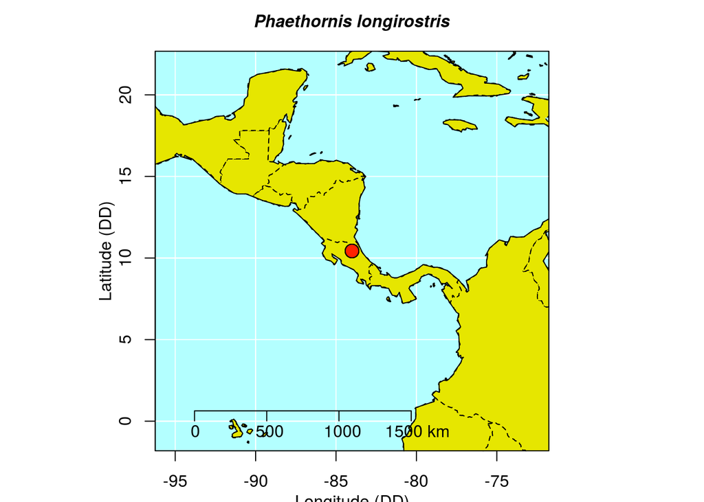

```r
# map in the RStudio graphics device (img = FALSE)
xcmaps(Phae.lon.LS, img = FALSE)
```

Once you’re sure you want the recordings, use `querxc` to download the files. It’s also a good idea to save the metadata as .csv files.

```r
# Download sound files
querxc(X = Phae.lon.LS)

# Save each data frame object as a .csv file
write.csv(Phae.lon.LS, "Phae_lon.LS.csv", row.names = FALSE)
```

### Convert [xeno-canto](http://www.xeno-canto.org/) *mp3* recordings to *wav* format

[xeno-canto](http://www.xeno-canto.org/) maintains recordings in *mp3* format due to file size restrictions. However, we require *wav* format for all downstream analyses. Compression from *wav* to *mp3* and back involves information losses, but recordings that have undergone this transformation have been successfully used in research <sup>[3]</sup>.

To convert *mp3* to *wav*, we can use the warbleR function `mp32wav`, which relies on a underlying function from the [`tuneR`](https://cran.r-project.org/package=tuneR) package. This function does not always work (and it remains unclear as to why!). This bug should be fixed in future versions of `tuneR`. If RStudio aborts when running `mp32wav`, use an *mp3* to *wav* converter online, or download the open source software `Audacity` (available for Mac, Linux and Windows users). We have made the selected *wav* files available for download (see next section).

After *mp3* files have been converted, we need to check that the *wav* files are not corrupted and can be read into RStudio (some *wav* files can’t be read due to format or permission issues).

```r
# Neither of these functions requires arguments
# Always check you're in the right directory beforehand
# getwd()
mp32wav()

# Use checkwavs to see if wav files can be read
checkwavs()

# Create a list of all the recordings in the directory
wavs <- list.files(pattern = "wav$")

# Downsample the wav files and speed up downstream analyses
invisible(lapply(wavs, function(x) writeWave(downsample(readWave(x), samp.rate = 22050),
                                  filename = x)))
```

## **Make long spectrograms of whole recordings**

The function `lspec` produces image files with spectrograms of whole sound files split into multiple rows. It is a useful tool for filtering by visual inspection.

`lspec` allows you to visually inspect the quality of the recording (e.g. amount of background noise) or the type, number, and completeness of the vocalizations of interest. You can discard the image files and recordings that you no longer want to analyze.

We should first adjust the function arguments to fit our recording characteristics. We can work on a subset of the recordings by specifying their names with the `flist` argument.

```r
# Create a list of all the recordings in the directory
wavs <- list.files(pattern = "wav$")

# Select a subset of recordings to explore lspec() arguments
# Based on the list of wav files we created above
sub <- wavs[c(1,3)]

# How long are these files? will determine number of pages returned by lspec
wavdur(sub)

# ovlp = 10 to speed up function
# tiff image files are better quality and are faster to produce
lspec(flist = sub, ovlp = 10, it = "tiff")

# We can zoom in on the frequency axis by changing flim,
# the number of seconds per row, and number of rows
lspec(flist = sub, flim = c(2, 10), sxrow = 6, rows = 15, ovlp = 10, it = "tiff")
```

Once satisfied with the argument settings we can run all files.

```r
lspec(flim = c(2, 10), ovlp = 10, sxrow = 6, rows = 15, it = "jpeg")

# concatenate lspec image files into a single PDF per recording
# lspec images must be jpegs
lspec2pdf(keep.img = FALSE, overwrite = TRUE)
```

The pdf image file (in the working directory) should look like this:

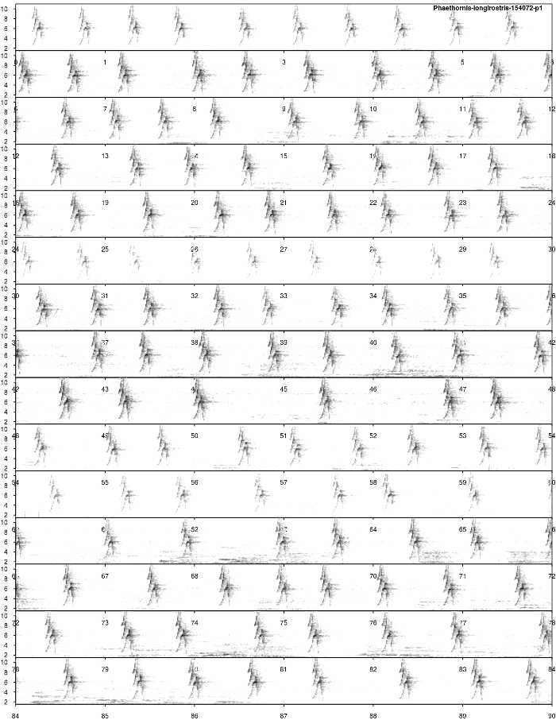

Note that the sound file name and page number are placed in the top right corner. Also, the dimensions of the image are made to letter paper size for printing and subsequent visual inspection.

Recording *154123* has a lot of background noise. Delete the *wav* file for this recording to remove it from subsequent analyses.

## **Select signals in *warbleR***

*warbleR* has two main functions for selecting acoustic signals within recordings: + `autodetec` - automatically detects the start and end of signals in sound files based on amplitude, duration, and frequency range attributes + `manualoc` - provides an interactive interface in the RStudio graphics device to manually select signals

Both functions work fastest with shorter recordings, but there are ways to deal with larger recordings (an hour long or more). In this section we have expanded on some important function arguments, but check out the function documentation for more information.

### Automatically detect signals with `autodetec`

Keep these points in mind when using `autodetec`:

1. **`autodetec` has 2 types of output:**
   - data frame with recording name, selection, start and end times. The last two are temporal coordinates that will be passed on to downstream functions to measure acoustic parameters. Save this output as an object or it will not be saved in the environment, but rather printed in the console.
   - a spectrogram per recording, with red dotted lines marking the start and end of each detected signal, saved in your working directory. In the case of long recordings, it’s preferable to create long spectrograms (`ls = TRUE`). For shorter recordings, spectrograms of individual selections may work better (`ls = FALSE`).
2. **Important detection parameters:**
   - `threshold` controls detection by relative amplitude (%)
   - `bp` serves as a frequency bandpass filter
   - `ssmooth` controls combination of window length and overlap to smooth signals that have many peaks and would otherwise be detected as multiple signals
   - `mindur` & `maxdur` determine the minimum and maximum duration of the signals to be detected
   - `set` dictates whether settings of the autodetection process are included in the image file name. If `set = TRUE`, threshold (th), envelope (envt), bandpass (bp), power (pw), smooth (smo), maxdur (mxdu), and mindur (midu) are included in image file names. This helps compare the performance of different detection setttings.

To set detection parameters we need to know the frequency range and duration of the signals we want to detect. *Phaenthornis longirostris* songs have frequencies between 2 and 10 kHz and durations between 0.05 and 0.5 s. Detecting signals is not a linear process. You will often need to run detection functions several times, and in the process you will get to know your signals better (if you don’t already).

If you need to detect all or most of the signals within the recording, play around with different arguments to increase detection accuracy. Since you may need to do several rounds of optimization, we recommend using subsets of your recordings to speed up the process. If the species you study produces stereotyped signals, like *Phaethornis longirostris*, just a few signals are needed per recording, and a low-accuracy detection could yield enough selections.

Finally, although `autodetec` performs automatic signal detection, it does not replace visual inspection of selected signals. Ensure that you set aside the time to inspect all selected signals for accuracy.

```r
# Select a subset of the recordings
wavs <- list.files(pattern = ".wav$", ignore.case = TRUE)

# Set a seed so we all have the same results
set.seed(1)
sub <- wavs[sample(1:length(wavs), 3)]

# Run autodetec() on subset of recordings
autodetec(flist = sub, bp = c(1, 10), threshold = 10, mindur = 0.05, maxdur = 0.5, envt="abs",
          ssmooth = 300, ls = TRUE, res = 100,
          flim = c(1, 12), wl = 300, set =TRUE, sxrow = 6, rows = 15,
          redo = FALSE, it = "tiff")
```

The image files (in the working directory) should look like this (shown below is recording ID 154161):

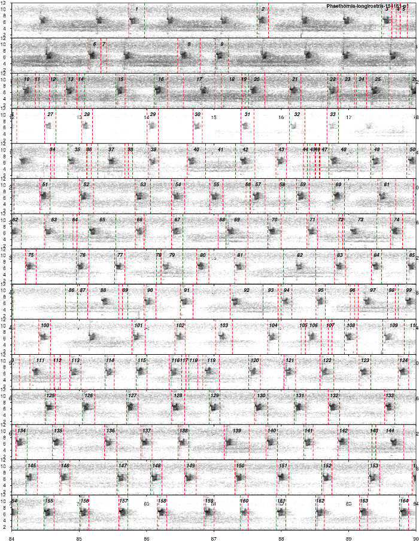

Note that some songs were correctly detected but other undersired sounds were also detected. In most cases, the undesired selections have a shorter duration than our target signals.

We won’t save the `autodetec` ouput in an object until we’re satisfied with the detection. To improve our detection we should play around with argument values. Below are some detection parameters that work well for these *Phaethornis longirotris* recordings:

```r
autodetec(flist = sub, bp = c(2, 10), threshold = 20, mindur = 0.09, maxdur = 0.22,
                     envt = "abs", ssmooth = 900, ls = TRUE, res = 100,
                     flim= c(1, 12), wl = 300, set =TRUE, sxrow = 6, rows = 15,
                     redo = TRUE, it = "tiff", img = TRUE, smadj = "end")
```

This seems to provide a good detection for most recordings (recording ID 154161):

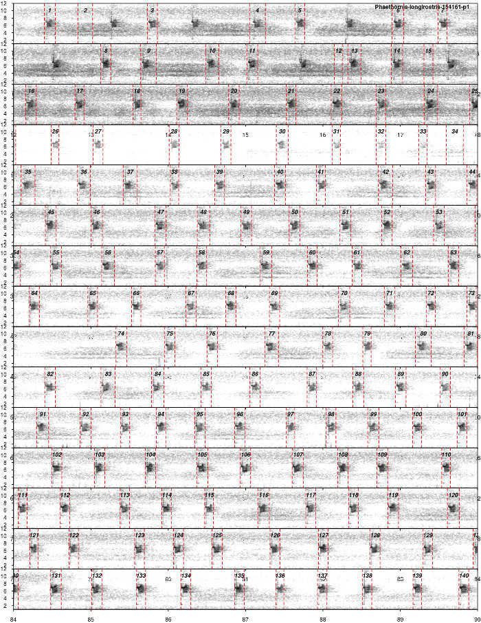

Once we’re satisfied with the detection, we can run the `autodetec` on all the recordings, removing the argument `flist` (so `autodetec` runs over all *wav* files in the working directory). We will also save the temporal output in an object.

```r
Phae.ad <- autodetec(bp = c(2, 10), threshold = 20, mindur = 0.09, maxdur = 0.22,
                     envt = "abs", ssmooth = 900, ls = TRUE, res = 100,
                     flim = c(2, 10), wl = 300, set =TRUE, sxrow = 6, rows = 15,
                     redo = TRUE, it = "tiff", img = TRUE, smadj = "end")
```

Let’s look at the number of selections per sound file:

```r
table(Phae.ad$sound.files)
```

### Select automatically detected signals using signal-to-noise ratio

Signal-to-noise ratio (SNR) can be a useful filter for automated signal detection. When background noise is detected as a signal it will have a low SNR, and this characteristic can be used to remove background noise from the `autodetec` selection table. SNR = 1 means the signal and background noise have the same amplitude, so signals with SNR <= 1 are poor quality. SNR calculations can also be used for different purposes throughout your analysis workflow.

#### Use `snrspecs` to optimize SNR measurements

`snrspecs` is another function in the family of spectrogram creators that allows you to pick a margin for measuring noise. These margins are very important for calculating SNR, especially when working with signals separated by short gaps (e.g. duets).

```r
# A margin that's too large causes other signals to be included in the noise measurement
# Re-initialize X as needed, for either autodetec or manualoc output

# Try this with 10% of the selections first
# Set a seed first, so we all have the same results
set.seed(5)

X <- Phae.ad[sample(1:nrow(Phae.ad),(nrow(Phae.ad)*0.1)), ]

snrspecs(X = X, flim = c(2, 10), snrmar = 0.5, mar = 0.7, it = "tiff")
```

The image files should look like this:

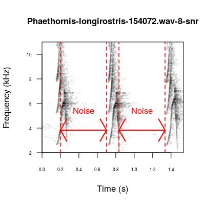

This margin overlaps signals, a smaller margin would be better.

```r
# This smaller margin is better
snrspecs(X = X, flim = c(2, 10), snrmar = 0.04, mar = 0.7, it = "tiff")
```

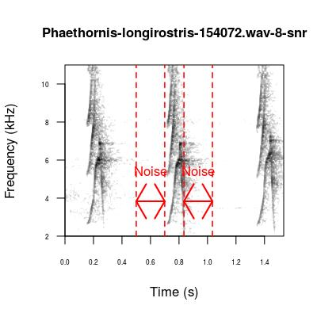

#### Calculate signal to noise ratio for recordings

Once we’ve picked an SNR margin we can move forward with the SNR calculation. We will measure SNR on every other selection to speed up the process.

```r
Phae.snr <- sig2noise(X = Phae.ad[seq(1, nrow(Phae.ad), 2), ], mar = 0.04)
```

As we just need a few songs to characterize each sound file and individual, we can choose selections with the highest SNR per sound file. In this example, we will choose 5 selections per recording with the highest SNRs.

```r
Phae.hisnr <- Phae.snr[ave(-Phae.snr$SNR, Phae.snr$sound.files, FUN = rank) <= 5, ]

# save the selections as a physical file
write.csv(Phae.hisnr, "Phae_hisnr.csv", row.names = FALSE)

# Double check the number of selection per sound files
table(Phae.hisnr$sound.files)
```

```
##
## Phaethornis-longirostris-154070.wav Phaethornis-longirostris-154072.wav
##                                   5                                   5
## Phaethornis-longirostris-154129.wav Phaethornis-longirostris-154138.wav
##                                   5                                   5
## Phaethornis-longirostris-154161.wav
##                                   5
```

### Manually select signals with `manualoc`

`manualoc` is a function that provides an interactive interface to select signals. We recommend reading the documentation for `manualoc` prior to running this example. Once you’ve done so, here are some points to keep in mind:

1. **The sole output for this function is a .csv file**:
   - contains the time coordinates, selection information and any comments made
2. **Be very precise with your clicks**
   - stray clicks will cause `manualoc` to fail
   - don’t double-click, instead click once and wait for blue bubble to pop up before clicking again
   - suspect a stray click when `manualoc` starts responding to single clicks
   - if so, stop `manualoc` with `Stop` button
   - `manualoc` retains all previous selections in the .csv file and will start up where you left off
3. **Selections can be deleted directly in the `manualoc` interface**
   - use `Del-sel` button
4. **Selections can also be deleted in the `manualoc_output.csv`**
   - stop `manualoc`, open the .csv
   - delete the rows corresponding to the unwanted selection(s) prior to starting `manualoc` again
5. **Run `manualoc` within the expected frequency range for your species**
   - use argument `flim` to facilitate signal selection
6. **Run `manualoc` with oscillograms enabled to improve signal selection**
   - when `osci = TRUE`, the oscillogram or waveform serves as a visual aid
   - use changes in amplitude to select start and end of the signal
   - the oscillogram will print to screen when the resolution of the projected spectrogram  
     improves (depends on the `seltime` argument)
   - `seltime` determines the time interval in seconds at which the spectrograms are produced with higher resolution and oscillograms

Some other uses for `manualoc`:

1. **`manualoc` can be used in combination with `autodetec` if you have large recordings:**
   - you can select specific time points to break up the recording and speed up `autodetec`
   - then you can feed these time coordinates to `autodetec` using the data frame argument `X`
2. **`manualoc` can also be used for visual classification:**
   - run `manualoc` with `selcomm = TRUE`
   - tag individual selections with song or element types using `selcomm`
   - use `specreator` to create spectrograms with `selcomm` text and check visual classifications

You can stop the function at any point by clicking twice on the `stop` button.

```r
# Run manualoc() with frequency range set for Phaethornis longirostris
# Recording comments are enabled to mark recording quality
# Selection comments enabled to include visual classifications
manualoc(flim = c(2, 10), reccomm = TRUE, selcomm = TRUE, osci = TRUE, seltime = 2)

# Read manualoc() output back into RStudio as an object
# This data frame object can be used as input for later functions
manualoc_out <- read.csv("manualoc_output.csv", header = TRUE)
```

The graphics device will look similar to this:

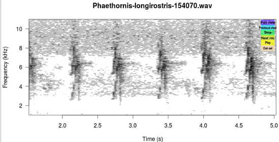

## *warbleR* interface with other bioacoustics software

*warbleR* is compatible with *Raven* and *Syrinx*. You may already work with these bioacoustics programs, and they are a valuable subset of the software available to a wide user base. One of the most difficult part of any biological analysis is transitioning between software, as this often involves writing customized code, or relying on yet other programs, to translate file formats. *warbleR* now contains functions that allow you to start an analysis outside of *R*, or take the analysis outside of *R* when necessary. Check out the following functions:

- `exp_raven` - export selections made in *warbleR* to *Raven*
- `imp.raven` - import selection tables from *Raven*
- `imp.syrinx` - import selection tables from *Syrinx*
- `run_raven` - open sound files in Raven from the R interface

The function `exp_raven` lets you take the analysis outside of *R* after making selections in *warbleR*.

### **Export selections made in *warbleR* to *Raven***

```r
Phae.hisnr <- read.csv("Phae_hisnr.csv", header = TRUE)

# remove SNR column and select the first sound file
sub <- droplevels(Phae.hisnr[Phae.hisnr$sound.files == levels(Phae.hisnr$sound.files)[1], -grep("SNR", names(Phae.hisnr))])

str(sub)

# extract recording name without ".wav" extension
# save filtered autodetec output as a Raven selection file
exp_raven(X = sub, file.name = paste(strsplit(unique(as.character(sub$sound.files)), split = ".w")[[1]][1], "hisnr", sep = "_"))
```

### **Open sound files in Raven from the R interface**

The function `run_raven` is particularly useful. It allows you to call *Raven* from *warbleR* and import selections you make in *Raven* directly back to *warbleR* as a data frame.

```r
# the object sels will contain selections you made in the target recordings
# use arguments from imp.raven to return selection table in correct format for warbleR functions
sels <- run_raven(raven.path = "~/opt/Raven-1.5.0.0035/", sound.files = c("Phaethornis-longirostris-154072.wav", "Phaethornis-longirostris-154070.wav"), at.the.time = 2, import = TRUE, all.data = FALSE, name.from.file = TRUE, ext.case = "lower", freq.cols = FALSE)
str(sels)

# write the imported selections as a .csv for later use
write.csv(sels, "Raven_sels.csv", row.names = FALSE)
```

```
## 'data.frame':    8 obs. of  6 variables:
##  $ sound.files: Factor w/ 2 levels "Phaethornis-longirostris-154070.wav",..: 1 1 1 1 2 2 2 2
##  $ selec.file : Factor w/ 2 levels "Phaethornis-longirostris-154070.Table.1.selections.txt",..: 1 1 1 1 2 2 2 2
##  $ channel    : int  1 1 1 1 1 1 1 1
##  $ selec      : int  1 2 3 4 1 2 3 4
##  $ start      : num  0.791 1.479 2.125 2.227 0.706 ...
##  $ end        : num  0.951 1.63 2.276 2.227 0.848 ...
```

### **Next vignette: Visual inspection and classification of signals**

Here we have given examples of how to begin the `warbleR` workflow. Note that there are many different ways to begin the workflow, depending on your question and source of data. After running the code in this first vignette, you should now have an idea of:

- the data used in *warbleR*
- how to obtain open-access *xeno-canto* recordings
- how to select signals for analysis in either:
  - recordings downloaded from *xeno-canto*
  - your own sound files
- how to use the `warbleR` interface with other bioacoustics programs, *Raven* and *Syrinx*

The next vignette will cover the second phase of the *warbleR* workflow, which includes methods to visualize signals for quality control and classification.

References

1. Araya-Salas, M. and G. Smith-Vidaurre. 2016. warbleR: an R package to streamline analysis of animal acoustic signals. *Methods in Ecology and Evolution*. doi: 10.1111/2041-210X.12624
2. Araya-Salas, M. and T. Wright. 2013. Open-ended song learning in a hummingbird. *Biology Letters*. 9 (5). doi: 10.1098/rsbl.2013.0625
3. Medina‐García, Angela, M. Araya‐Salas, and T. Wright. 2015. Does vocal learning accelerate acoustic diversification? Evolution of contact calls in Neotropical parrots. *Journal of Evolutionary Biology*. doi: 10.1111/jeb.12694